# Estimación no paramétrica

Authors

Affiliations

Félix Belzunce

Universidad de Murcia

María del Carmen Bueso, Pilar Sanmartín

Universidad Politécnica de Cartagena

# Introducción

El objetivo de esta práctica es presentar en `R` las herramientas estadísticas para la estimación de la función de distribución y la función de densidad. Como hemos comentado en clase, la estimación de la función puntual de probabilidad se realiza a través de las correspondientes proporciones muestrales. Recordamos que la estimación de la función de distribución se realiza a través de la función de distribución empírica y la estimación de la función de densidad a través de los estimadores tipo núcleo.

# Función de distribución empírica

Dada una variable aleatoria $X$ con función de distribución $F(x)=P(X\le x)$, tenemos que el estimador de $F$ es la *función de distribución empírica* que viene dada por
$$F_n(x)=\frac{\sum_{i=1}^n I_{(-\infty,x]}(X_i)}{n} \text{ para todo }x\in \mathbb R,$$
dada un m.a.s., $X_1,\ldots,X_n$, de $X$.

Veamos como está implementado su cálculo en `R`. La función que utilizaremos es la función `ecdf`.

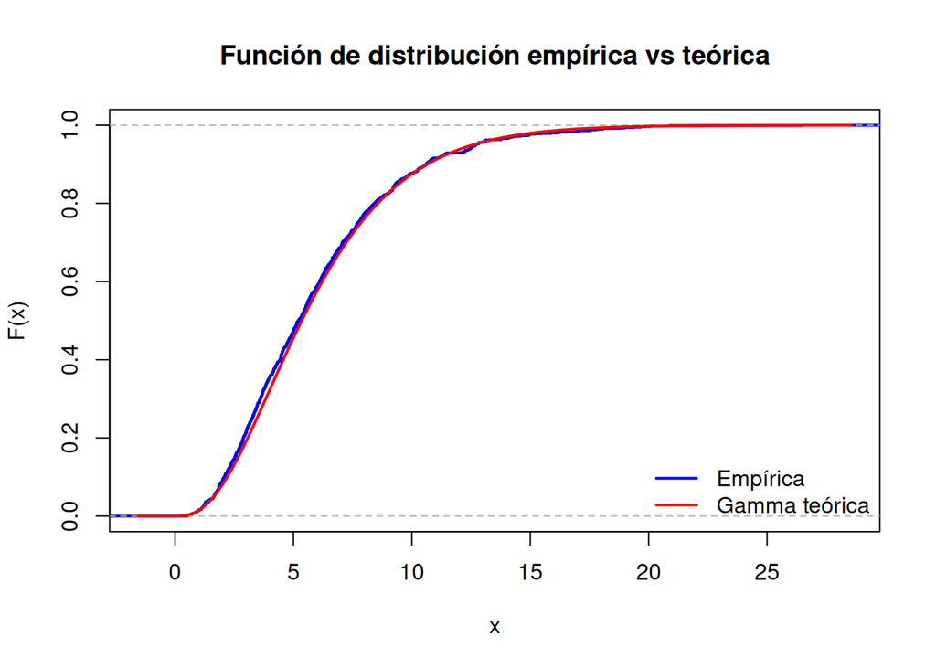

```r
# Completar aquí
library(tidyverse)

set.seed(314159)
x <- rgamma(1000, shape = 3, scale = 2)

Fn <- ecdf(x)

plot(
  Fn,
  verticals = TRUE,
  do.points = FALSE,
  col = "blue",
  lwd = 2,
  main = "Función de distribución empírica vs teórica",
  xlab = "x",
  ylab = "F(x)",
)
curve(
  pgamma(x, shape = 3, scale = 2),
  add = TRUE,
  col = "red",
  lwd = 2,
)
legend(
  "bottomright",
  legend = c("Empírica", "Gamma teórica"),
  col = c("blue", "red"),
  lwd = "2",
  bty = "n"
)
```

```r
# Fin Completar aquí
```

Podemos ver en este caso la buena aproximación de la distribución teórica a través de la función de distribución empírica.

# Estimación tipo núcleo

Siguiendo la notación anterior, en este caso se trata de estimar la función de densidad, $f(x)=F'(x)$, de la variable $X$.

Los estimadores de la función de densidad vistos en clase se conocen como *estimadores tipo núcleo* y su expresión general viene dada por
$$\hat f_n(x)=\frac{1}{2nh_n}\sum_{i=1}^n K\left(\frac{x-X_i}{h_n}\right),$$
donde $K$ es una función núcleo y $h_n$ es lo que se conoce como el ancho de banda.

Veamos como obtener este estimador con `R` para diferentes núcleos y diferentes anchos de banda. La función que nos permite obtener la estimación tipo núcleo es `density`.

Recordamos que los núcleos vistos en teoría:

- **Núcleo rectangular:** $K$ es la función de densidad de una distribución uniforme.
- **Núcleo normal:** $K$ es la función de densidad de una distribución normal estándar. Suele ser el núcleo que más se utiliza.
- **Núcleo de Epanechnikov:** $K(z)=(1-z^2)I_{(-1,1)}$. Se considera que es el núcleo más eficiente.

donde estos dos últimos son los más utilizados.

Veamos un ejemplo con cada núcleo.

- Núcleo rectangular:

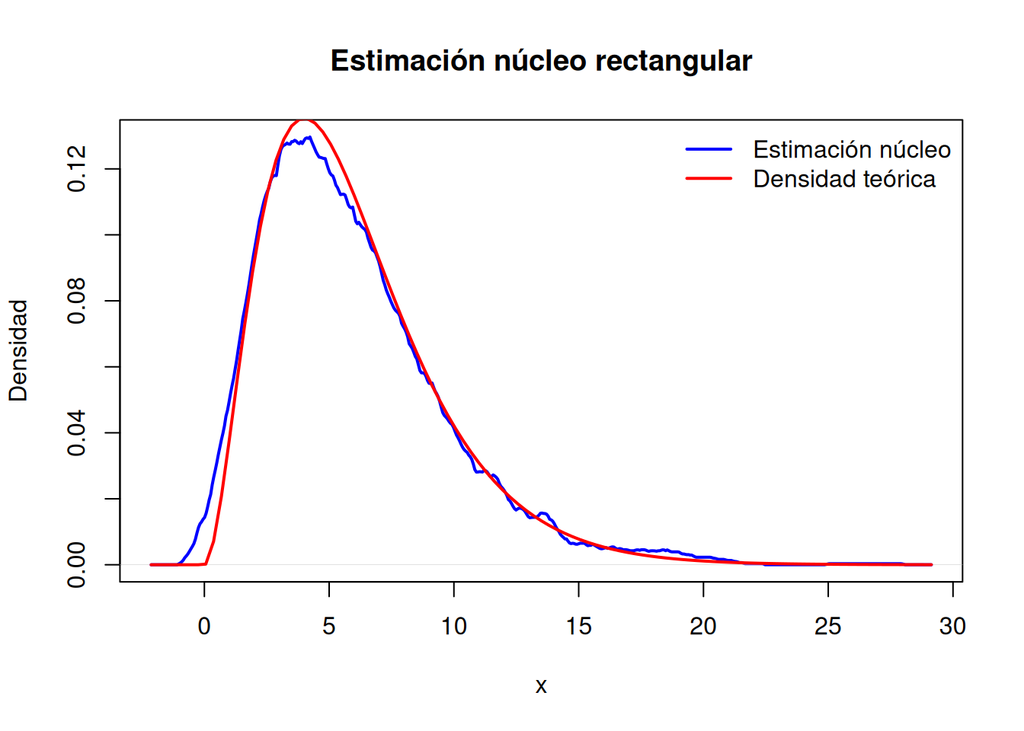

```r
# Completar aquí
dens_rect <- density(x, kernel = "rectangular", bw = "nrd")

plot(
  dens_rect,
  col = "blue",
  lwd = 2,
  main = "Estimación núcleo rectangular",
  xlab = "x",
  ylab = "Densidad",
)
curve(
  dgamma(x, shape = 3, scale = 2),
  add = TRUE,
  col = "red",
  lwd = 2,
)
legend(
  "topright",
  legend = c("Estimación núcleo", "Densidad teórica"),
  col = c("blue", "red"),
  lwd = 2,
  bty = "n"
)
```

```r
# Fin Completar aquí
```

- Núcleo normal:

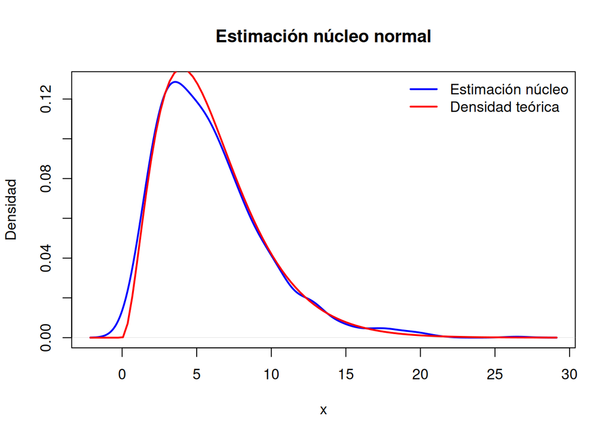

```r
# Completar aquí
dens_norm <- density(x, kernel = "gaussian", bw = "nrd")

plot(
  dens_norm,
  col = "blue",
  lwd = 2,
  main = "Estimación núcleo normal",
  xlab = "x",
  ylab = "Densidad"
)
curve(
  dgamma(x, shape = 3, scale = 2),
  add = TRUE,
  col = "red",
  lwd = 2
)
legend(
  "topright",
  legend = c("Estimación núcleo", "Densidad teórica"),
  col = c("blue", "red"),
  lwd = 2,
  bty = "n"
)
```

```r
# Fin Completar aquí
```

- Para el caso del núcleo de Epanechnikov tendríamos:

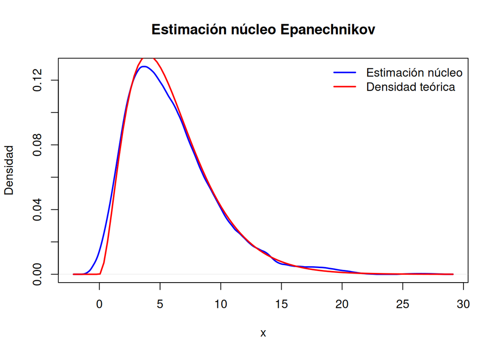

```r
# Completar aquí
dens_epan <- density(x, kernel = "epanechnikov", bw = "nrd")

plot(
  dens_epan,
  col = "blue",
  lwd = 2,
  main = "Estimación núcleo Epanechnikov",
  xlab = "x",
  ylab = "Densidad"
)
curve(
  dgamma(x, shape = 3, scale = 2),
  add = TRUE,
  col = "red",
  lwd = 2,
)
legend(
  "topright",
  legend = c("Estimación núcleo", "Densidad teórica"),
  col = c("blue", "red"),
  lwd = 2,
  bty = "n"
)
```

```r
# Fin Completar aquí
```

Como vemos, sobre todo en los dos tipos últimos casos, hay una aproximación bastante buena entre el valor real y la aproximación mediante el estimador tipo núcleo. Nos vamos a centrar en el estudio del núcleo normal y el de Epanechnikov.

La elección del ancho de banda se basa en la fórmula general:
$$h_n=\left( \frac{R(K)}{\mu_2^2(K)R(f'')n} \right)^{\frac{1}{5}},$$
donde los valores $R(K)$ y $\mu_2(K)$ dependen del núcleo $K$ y $R(f'')$ depende de la función de densidad de la variable (ver los detalles en los apuntes del tema). Esto último presenta un problema ya que el término $R(f'')$ depende de la función de densidad que es desconocida y por tanto no se pude calcular su valor exacto.

Bajo ciertas condiciones, variable con distribución normal y núcleo normal, la expresión anterior queda como
$$\hat h_{n,RP}=\left( \frac{4}{3n}\right)^{1/5}S,$$
y se conoce como “regla del pulgar”. Es el valor usado en los ejemplos anteriores, y se especifica en el argumento `bw` como `"nrd"`.

La forma más complicada de evaluar es dando una estimación no paramétrica de $R(f'')$. La metodología va más allá de los contenidos de esta asignatura y no veremos los detalles, solo indicar que podemos seleccionarla en el argumento `bw` como `"SJ"`.

Vamos a reproducir las gráficas de antes con esta elección del ancho de banda.

Caso con núcleo normal:

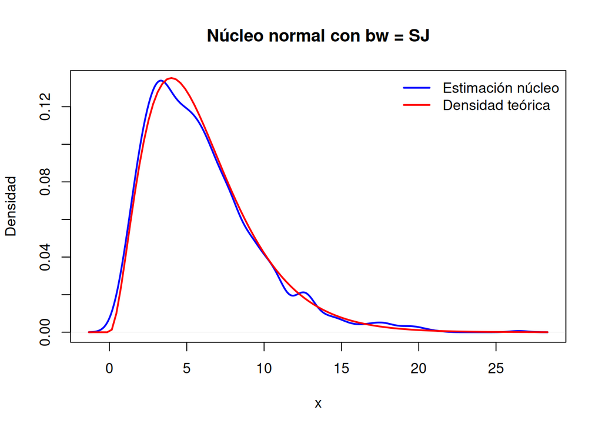

```r
# Completar aquí
dens_norm_sj <- density(x, kernel = "gaussian", bw = "SJ")

plot(
  dens_norm_sj,
  col = "blue",
  lwd = 2,
  main = "Núcleo normal con bw = SJ",
  xlab = "x",
  ylab = "Densidad"
)
curve(
  dgamma(x, shape = 3, scale = 2),
  add = TRUE,
  col = "red",
  lwd = 2
)
legend(
  "topright",
  legend = c("Estimación núcleo", "Densidad teórica"),
  col = c("blue", "red"),
  lwd = 2,
  bty = "n"
)
```

```r
# Fin Completar aquí
```

Caso con núcleo Epanechnivok:

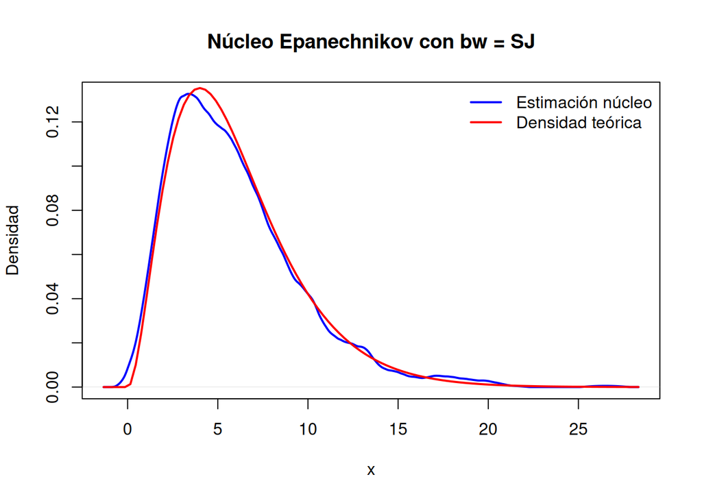

```r
# Completar aquí
dens_epan_sj <- density(x, kernel = "epanechnikov", bw = "SJ")

plot(
  dens_epan_sj,
  col = "blue",
  lwd = 2,
  main = "Núcleo Epanechnikov con bw = SJ",
  xlab = "x",
  ylab = "Densidad"
)
curve(
  dgamma(x, shape = 3, scale = 2),
  add = TRUE,
  col = "red",
  lwd = 2
)
legend(
  "topright",
  legend = c("Estimación núcleo", "Densidad teórica"),
  col = c("blue", "red"),
  lwd = 2,
  bty = "n"
)
```

```r
# Fin Completar aquí
```

# Ejercicio

Vamos a analizar datos del contexto de empresas. Para ello, vamos a considerar los datos que aparecen en el fichero `salarios.sav` donde tenemos 935 observaciones aleatorias de variables que se corresponden con datos de empleados de una gran corporación (Uriel,R y Aldás,J. “Análisis Multivariante aplicado con R”. Ed. Paraninfo). en particular nos vamos a centrar en la variable salario.

Obten el gráfico de la función de distribución empírica de la variable y superponla con la correspondiente gráfica de una la distribución normal con media y varianza las estimadaa partir de los datos. A partir de la gráfica anterior comenta si parece razonable considerar que los datos provienen de una distribución normal.

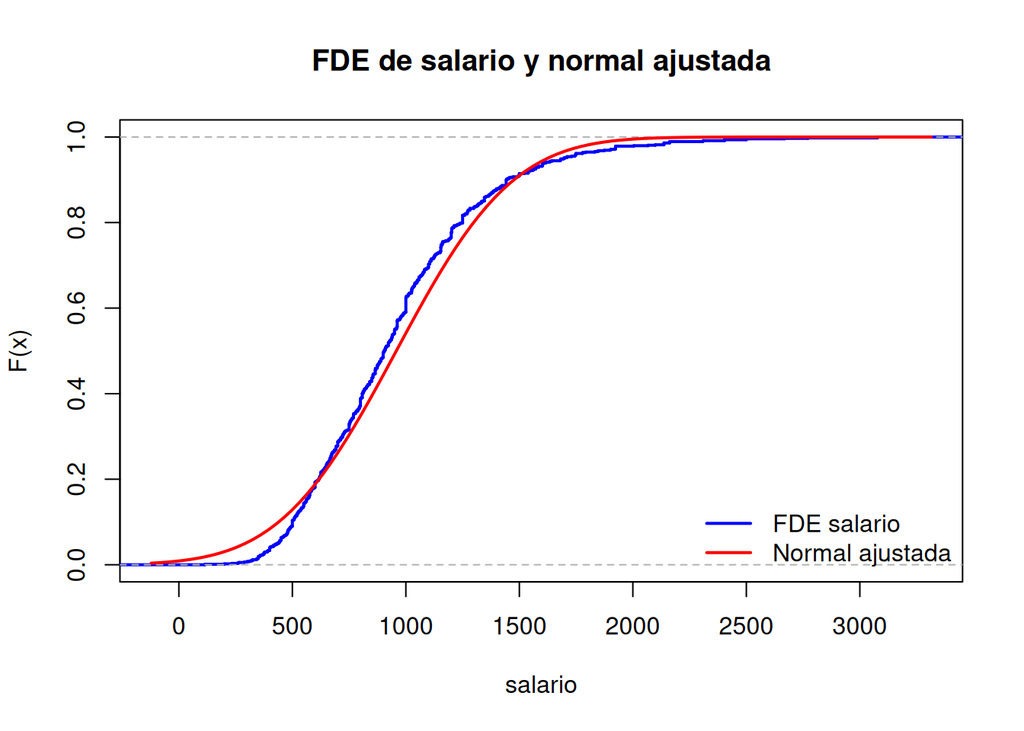

```r
# Completar aquí
library(haven)

datos <- read_sav("../data/salarios.sav")

nombre_salario <- names(datos)[str_detect(tolower(names(datos)), "sal")]
if (length(nombre_salario) == 0) {
  nombre_salario <- names(datos)[map_lgl(datos, is.numeric)][1]
}

salario <- as.numeric(datos[[nombre_salario[1]]])
salario <- salario[is.finite(salario)]

mu_hat <- mean(salario)
sd_hat <- sd(salario)

Fn_sal <- ecdf(salario)

plot(
  Fn_sal,
  verticals = TRUE,
  do.points = FALSE,
  col = "blue",
  lwd = 2,
  main = "FDE de salario y normal ajustada",
  xlab = "salario",
  ylab = "F(x)",
)
curve(
  pnorm(x, mean = mu_hat, sd = sd_hat),
  add = TRUE,
  col = "red",
  lwd = 2,
)
legend(
  "bottomright",
  legend = c("FDE salario", "Normal ajustada"),
  col = c("blue", "red"),
  lwd = 2,
  bty = "n"
)
```

```r
# Fin Completar aquí
```

Obtener la estimaciones tipo núcleo de la función de densidad de la variable anterior, utilizando los núcleos normal y Epanechnikov. Comenta la forma que se obtiene de la función de densidad en cada caso.

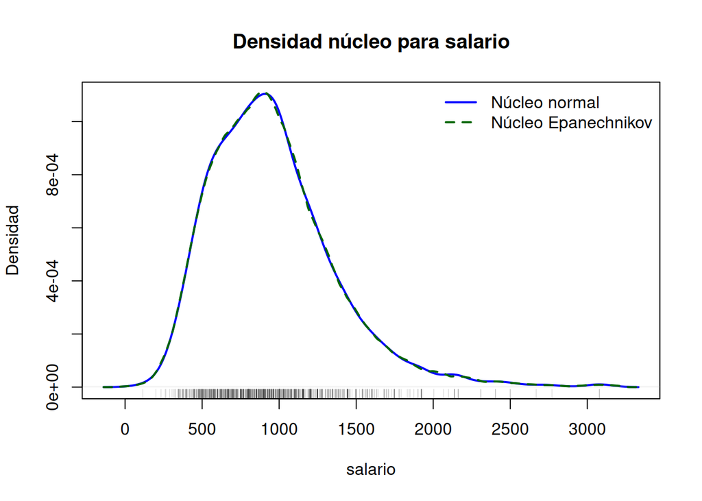

```r
# Completar aquí
dens_sal_norm <- density(salario, kernel = "gaussian", bw = "SJ")
dens_sal_epan <- density(salario, kernel = "epanechnikov", bw = "SJ")

plot(
  dens_sal_norm,
  col = "blue",
  lwd = 2,
  main = "Densidad núcleo para salario",
  xlab = "salario",
  ylab = "Densidad"
)
lines(dens_sal_epan, col = "darkgreen", lwd = 2, lty = 2)
rug(salario, col = "#00000033")
legend(
  "topright",
  legend = c("Núcleo normal", "Núcleo Epanechnikov"),
  col = c("blue", "darkgreen"),
  lwd = 2,
  lty = c(1, 2),
  bty = "n"
)
```

```r
# Fin Completar aquí
```

Realiza el mismo análisis pero con los datos transformados por el logaritmo neperiano.

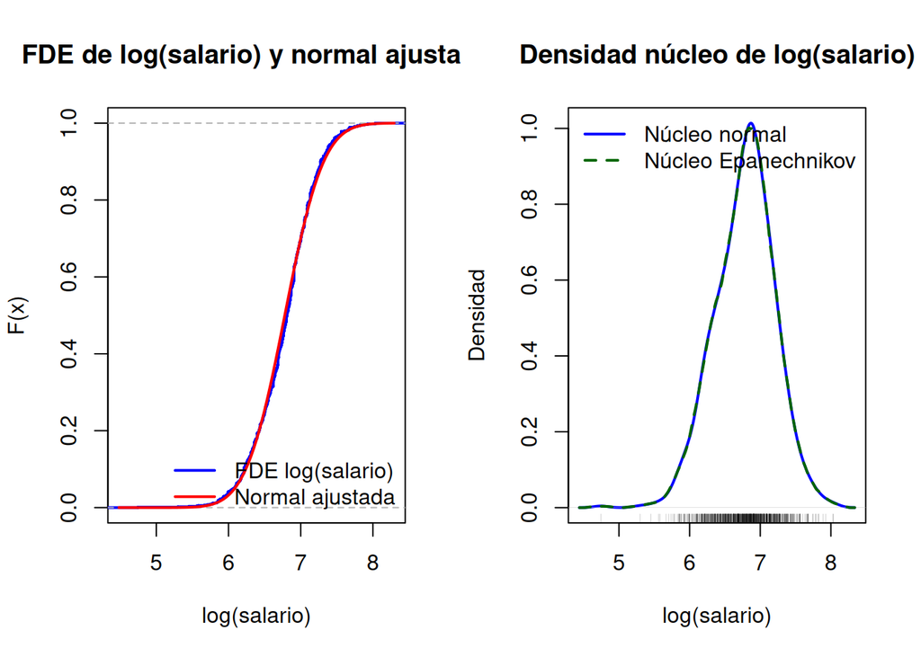

```r
# Completar aquí
log_salario <- log(salario[salario > 0])

mu_log <- mean(log_salario)
sd_log <- sd(log_salario)

op <- par(mfrow = c(1, 2))

Fn_log <- ecdf(log_salario)
plot(
  Fn_log,
  verticals = TRUE,
  do.points = FALSE,
  col = "blue",
  lwd = 2,
  main = "FDE de log(salario) y normal ajustada",
  xlab = "log(salario)",
  ylab = "F(x)"
)
curve(
  pnorm(x, mean = mu_log, sd = sd_log),
  add = TRUE,
  col = "red",
  lwd = 2
)
legend(
  "bottomright",
  legend = c("FDE log(salario)", "Normal ajustada"),
  col = c("blue", "red"),
  lwd = 2,
  bty = "n"
)

dens_log_norm <- density(log_salario, kernel = "gaussian", bw = "SJ")
dens_log_epan <- density(log_salario, kernel = "epanechnikov", bw = "SJ")

plot(
  dens_log_norm,
  col = "blue",
  lwd = 2,
  main = "Densidad núcleo de log(salario)",
  xlab = "log(salario)",
  ylab = "Densidad"
)
lines(dens_log_epan, col = "darkgreen", lwd = 2, lty = 2)
rug(log_salario, col = "#00000033")
legend(
  "topright",
  legend = c("Núcleo normal", "Núcleo Epanechnikov"),
  col = c("blue", "darkgreen"),
  lwd = 2,
  lty = c(1, 2),
  bty = "n"
)
```

```r
par(op)
# Fin Completar aquí
```